# Plotting in R Quick Reference

Mark Niemann-Ross

2/6/2021

# About

## About This Document

This document provides brief explanations of the plotting functions available in Base R and the lattice package. It does not cover the [tidyverse or ggplot](https://rstudio.com/resources/cheatsheets/) - Rstudio does a great job of that without my help.

## Related Material

This Quick Reference is supplemental to courses on [LinkedIn Learning](https://www.linkedin.com/learning/r-for-data-science-lunchbreak-lessons/). A quick reference to [matrix math functions in R is here](http://niemannross.com/link/rmatrixqref). A quick reference to [clustering functions in R is here](http://niemannross.com/link/rclusterqref). An index to all R functions covered at LinkedIn Learning is found [here](http://niemannross.com/link/rindex). The latest version of this quick reference is found [here](http://niemannross.com/link/rplotqref). The source to this document is found on [github/mnr](https://github.com/mnr/R-for-Data-Science-Lunchbreak-Lessons). This document is available as Free Software under the terms of the [Free Software Foundation’s](http://www.gnu.org/) [GNU General Public License](https://www.r-project.org/COPYING).

## About Mark Niemann-Ross

[Mark](https://niemannross.com/) is an author for LinkedIn Learning and writes Science Fiction.

# plot

[Instructional video on plot()](https://linkedin-learning.pxf.io/plot)

The simplest of all plots

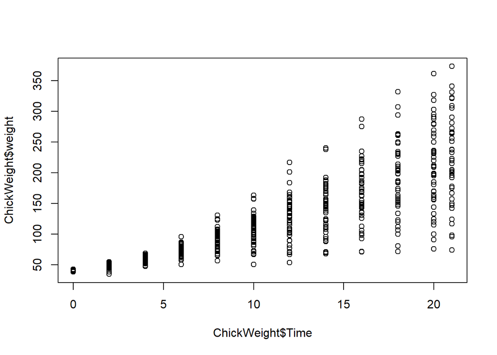

```r
plot(ChickWeight$Time,ChickWeight$weight)
```

Change the appearance of the plotted points

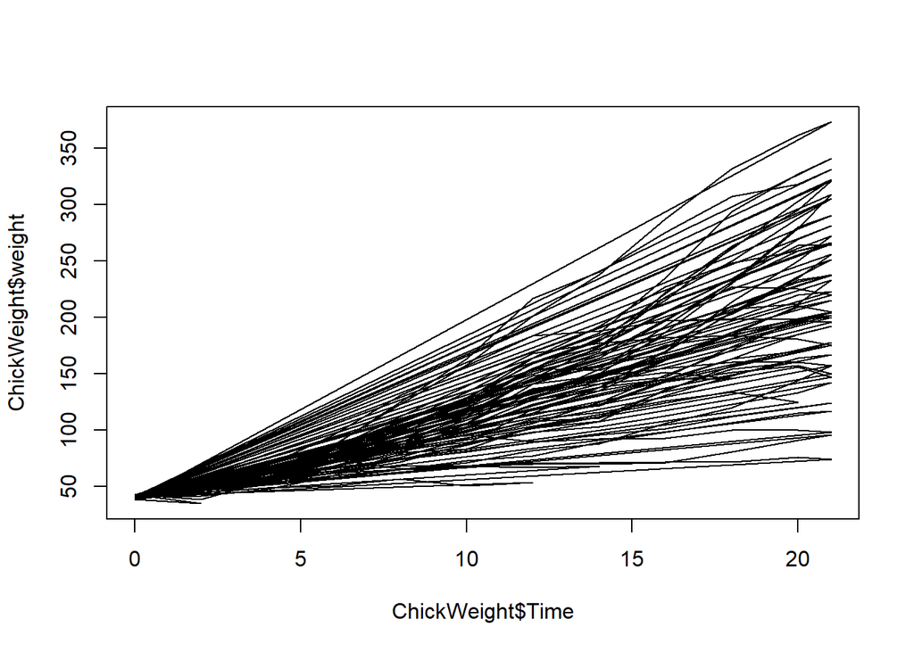

```r
plot(ChickWeight$Time,ChickWeight$weight,type = "l")
```

setting the titles and labels

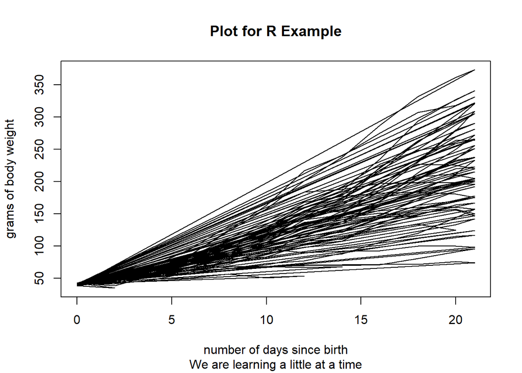

```r
plot(ChickWeight$Time,ChickWeight$weight,
     type = "l",
     main = "Plot for R Example",
     sub = "We are learning a little at a time",
     xlab="number of days since birth",
     ylab="grams of body weight")
```

add another line to a plot

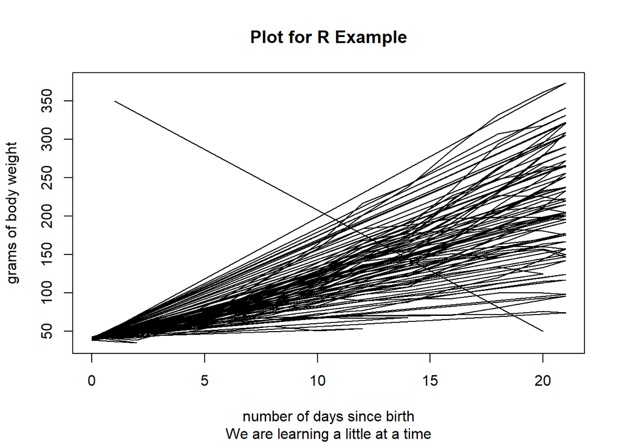

```r
plot(ChickWeight$Time,ChickWeight$weight,
     type = "l",
     main = "Plot for R Example",
     sub = "We are learning a little at a time",
     xlab="number of days since birth",
     ylab="grams of body weight")

lines(c(1,20),c(350,50))
```

change the appearance of the graph

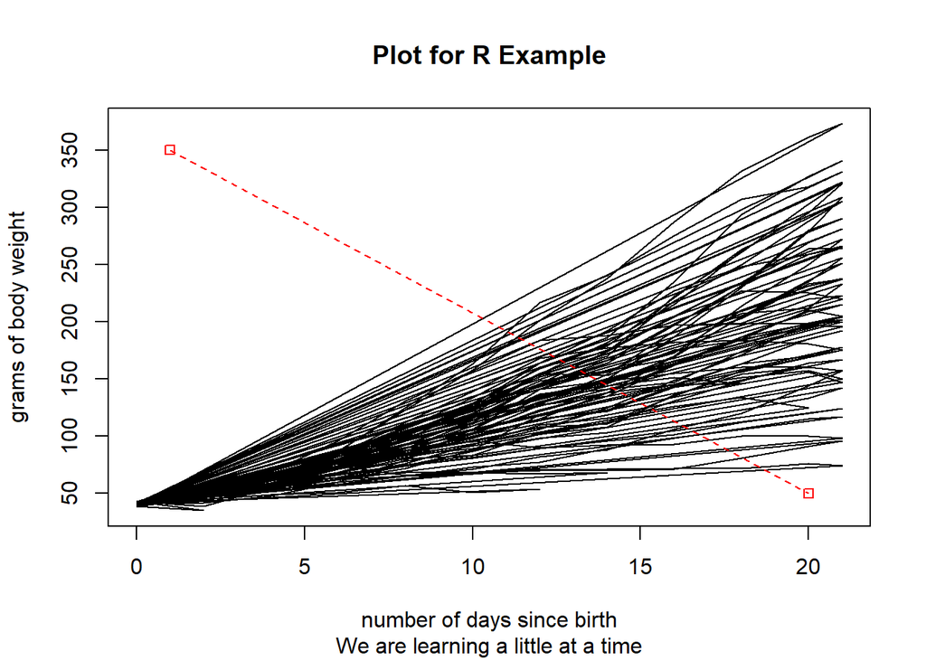

```r
plot(ChickWeight$Time,ChickWeight$weight,
     type = "l",
     main = "Plot for R Example",
     sub = "We are learning a little at a time",
     xlab="number of days since birth",
     ylab="grams of body weight")
lines(c(1,20),c(350,50), type="o", pch=22, lty=2, col="red")
```

You can also use functions as x and y arguments

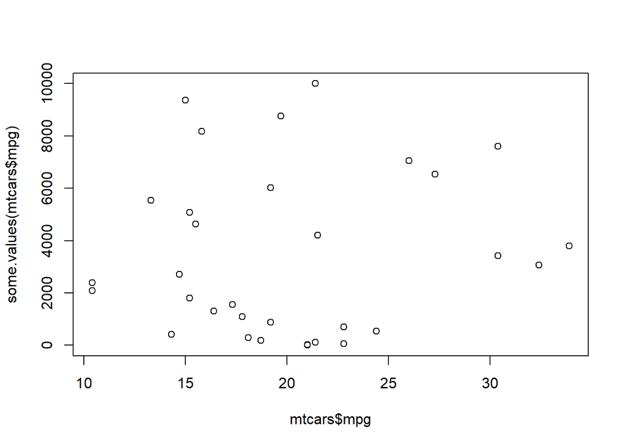

```r
some.values <- function(my.something) {
  return(seq(from=1, to=100,length.out = length(my.something))^2)
  }
plot(mtcars$mpg,some.values(mtcars$mpg))
```

Here’s a clever trick - put a plot in a function

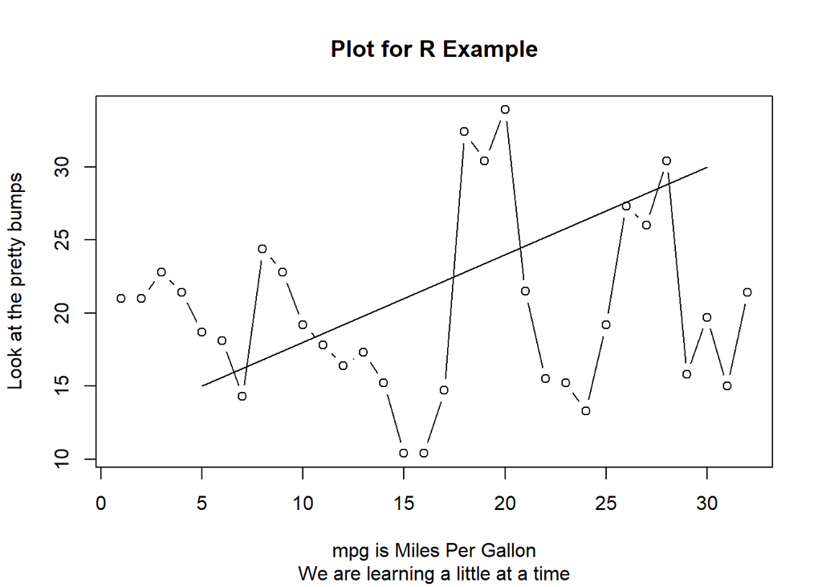

```r
plotThis <- function(lineX,lineY) {plot(mtcars$mpg,
     type = "b",
     main = "Plot for R Example",
     sub = "We are learning a little at a time",
     xlab="mpg is Miles Per Gallon",
     ylab="Look at the pretty bumps")
lines(lineX,lineY)
}
plotThis(c(5,30),c(15,30))
```

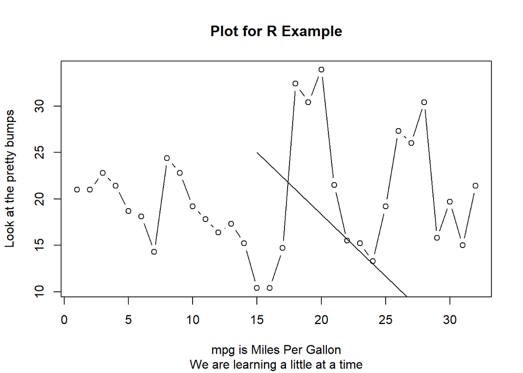

```r
plotThis(c(15,30),c(25,5))
```

# conditional density plot

[Instructional video on cdplot()](https://linkedin-learning.pxf.io/rweekly_cdplot)

Suppose you are doing research: given a certain amount of time, how much should a chick weigh?

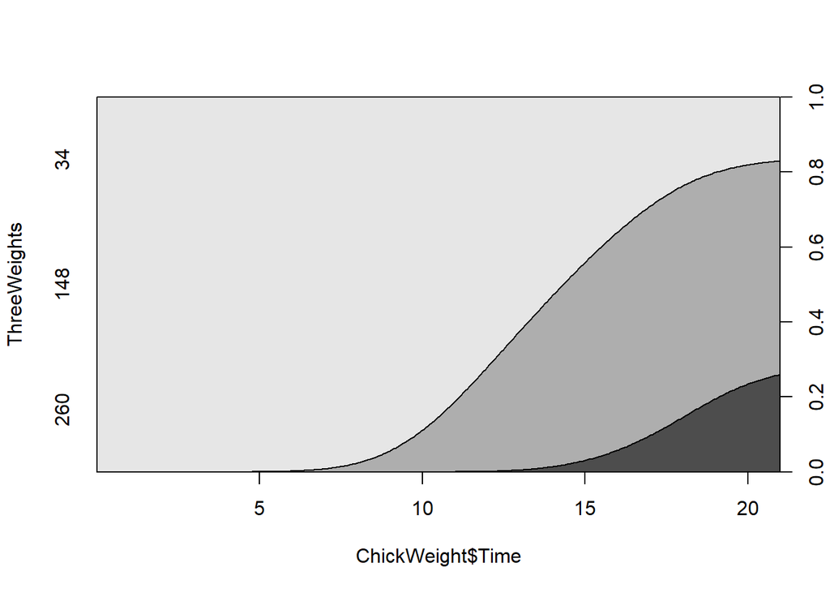

```r
# because conditional density plots require a factor
ThreeWeights <- cut(ChickWeight$weight, 3, labels = c(34, 148, 260))

cdplot(ChickWeight$Time, ThreeWeights)
```

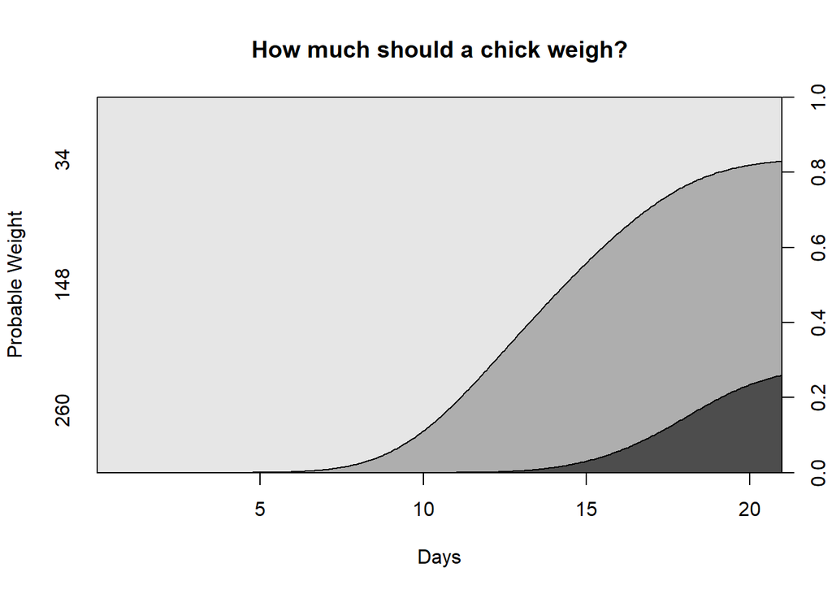

```r
cdplot(ChickWeight$Time, ThreeWeights,
       main = "How much should a chick weigh?",
       ylab = "Probable Weight",
       xlab = "Days"
)
```

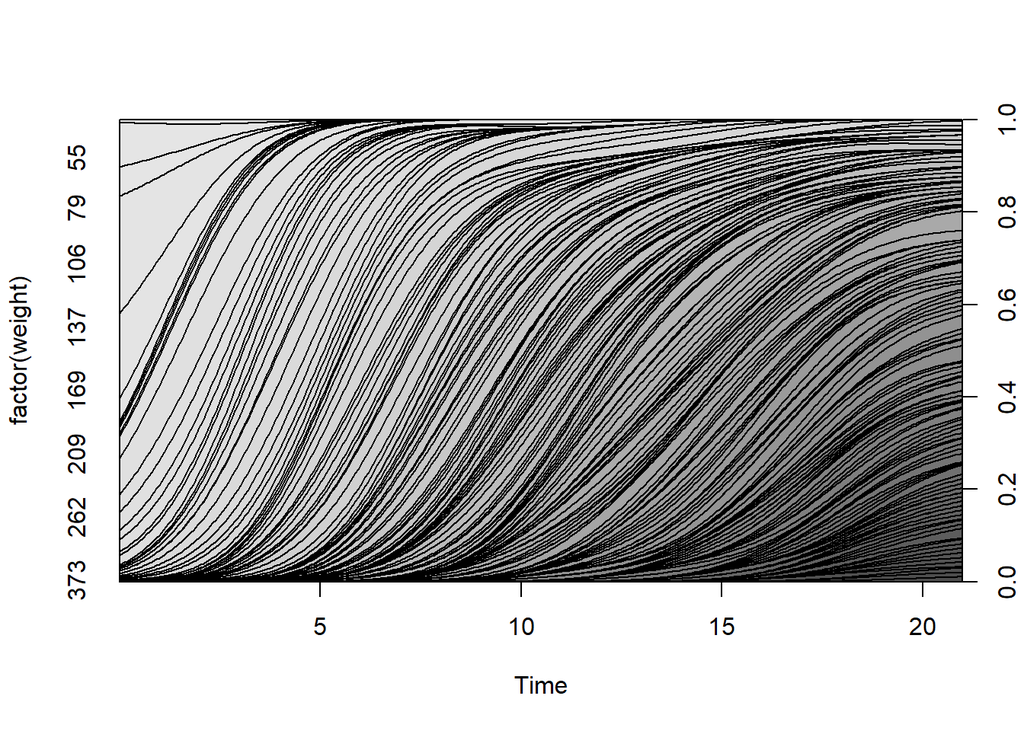

```r
# can you say "overplotting"
cdplot(factor(weight) ~ Time, data = ChickWeight)
```

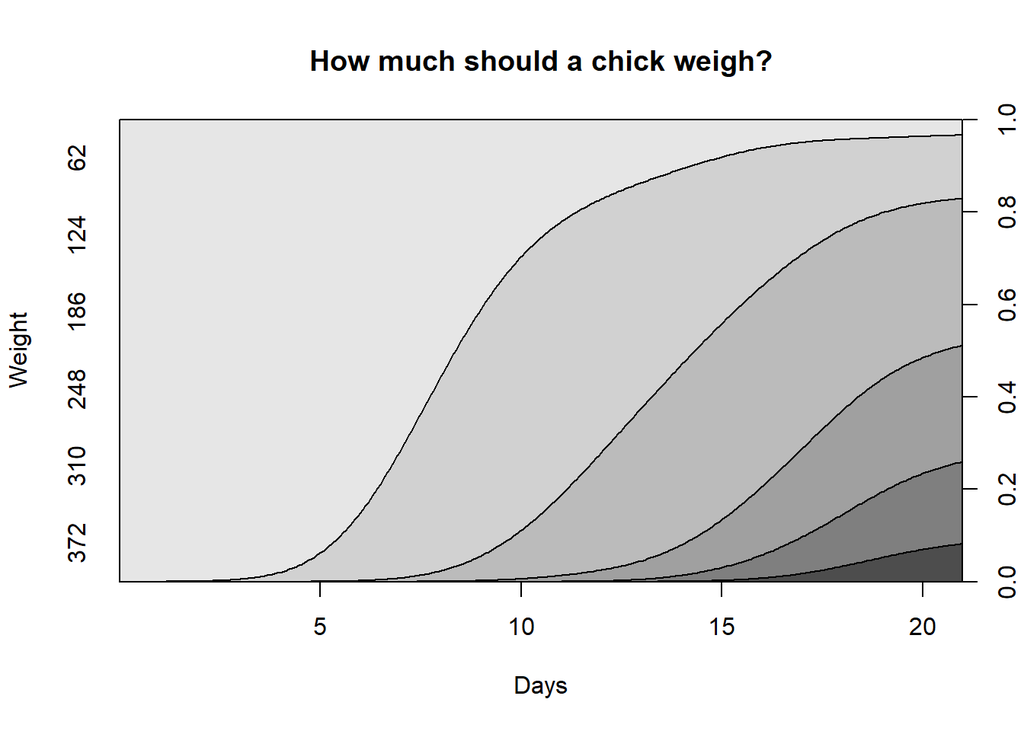

```r
# let's fix the overplot with cut()
cdplot(factor(cut(weight, 6, labels = 1:6 * 62)) ~ Time,
       data = ChickWeight,
       main = "How much should a chick weigh?",
       ylab = "Weight",
       xlab = "Days"
       )
```

# boxplot

[Instructional video on boxplot()](https://linkedin-learning.pxf.io/rweekly_boxplot)

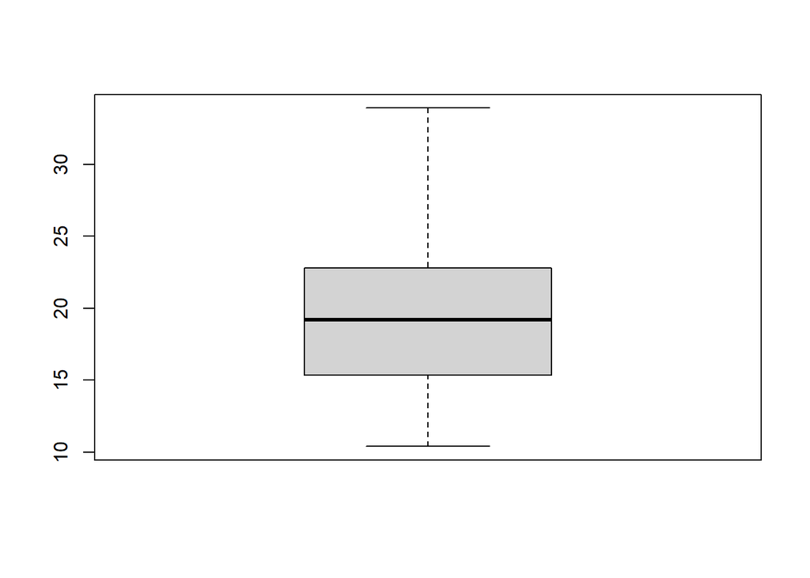

```r
boxplot(mtcars$mpg)
```

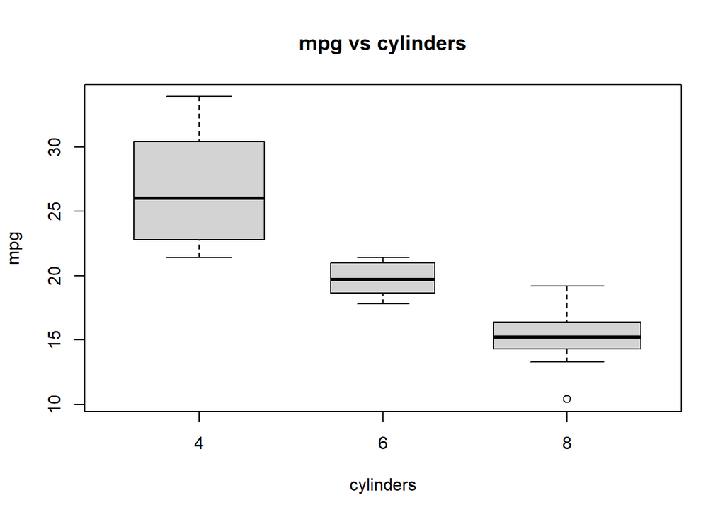

```r
boxplot(mpg ~ cyl, data = mtcars, col = "lightgray", varwidth = TRUE,
        main = "mpg vs cylinders",
        ylab = "mpg",xlab = "cylinders")
```

```r
# Here are the numbers used to create the boxplot
fivenum(mtcars$mpg)
```

```
## [1] 10.40 15.35 19.20 22.80 33.90
```

# Histogram

[Instructional video on hist()](https://linkedin-learning.pxf.io/rweekly_histogram)

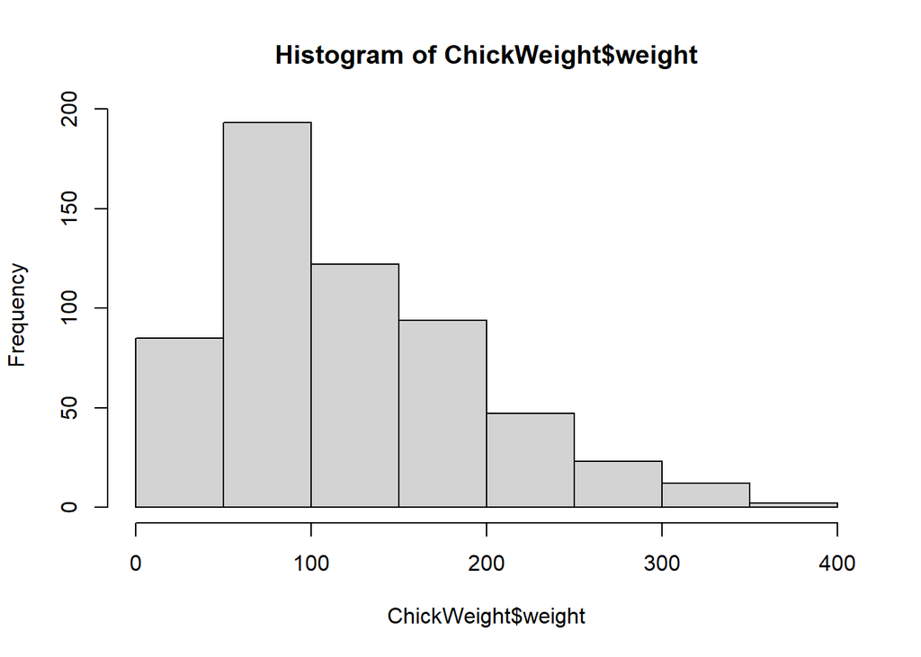

```r
hist(ChickWeight$weight)
```

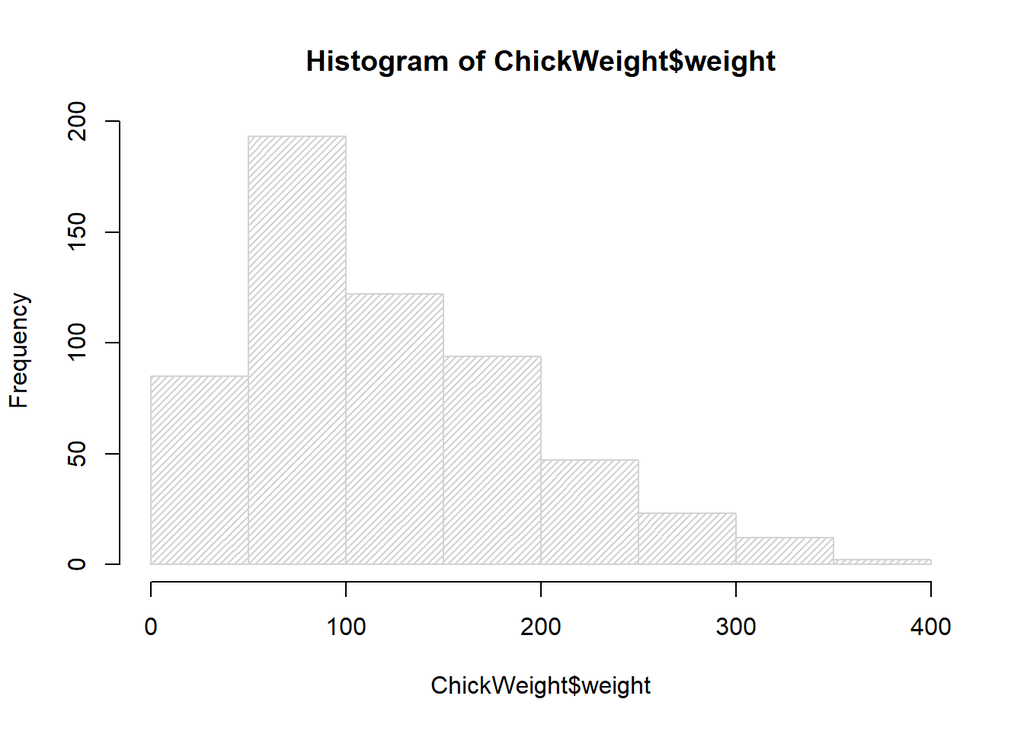

```r
hist(ChickWeight$weight, density = 30)
```

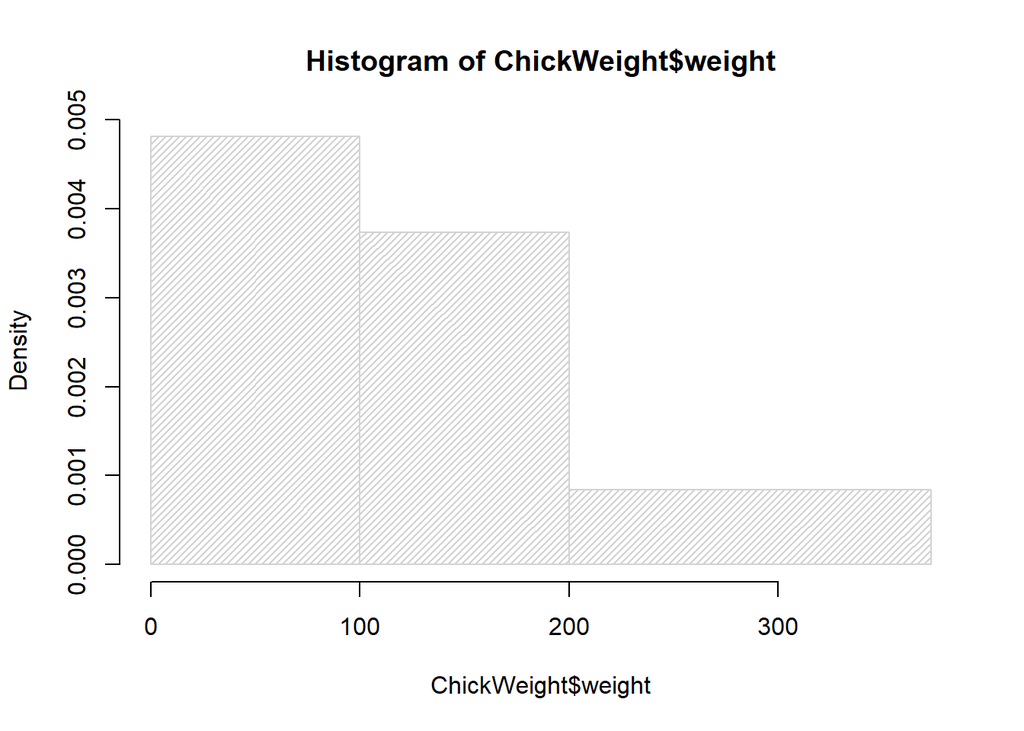

```r
hist(ChickWeight$weight, density = 30, breaks = c(0,100,200,max(ChickWeight$weight)))
```

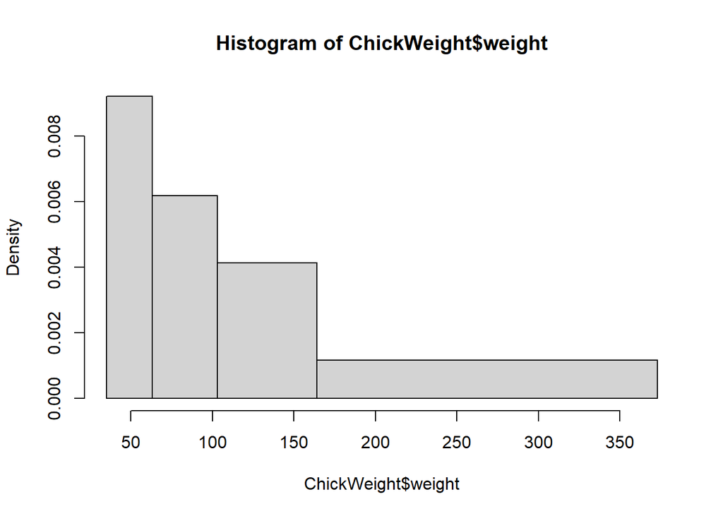

```r
hist(ChickWeight$weight, breaks = fivenum(ChickWeight$weight))
```

# coplot

[Instructional video on coplot()](https://linkedin-learning.pxf.io/rweekly_coplot)

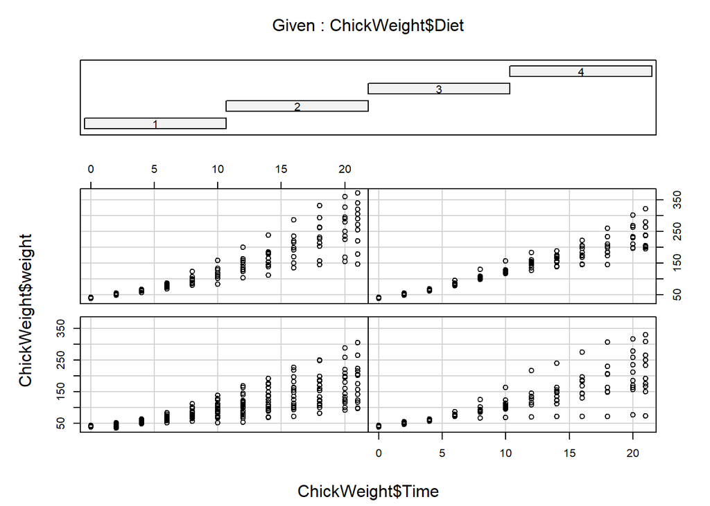

```r
coplot(ChickWeight$weight ~ ChickWeight$Time | ChickWeight$Diet)
```

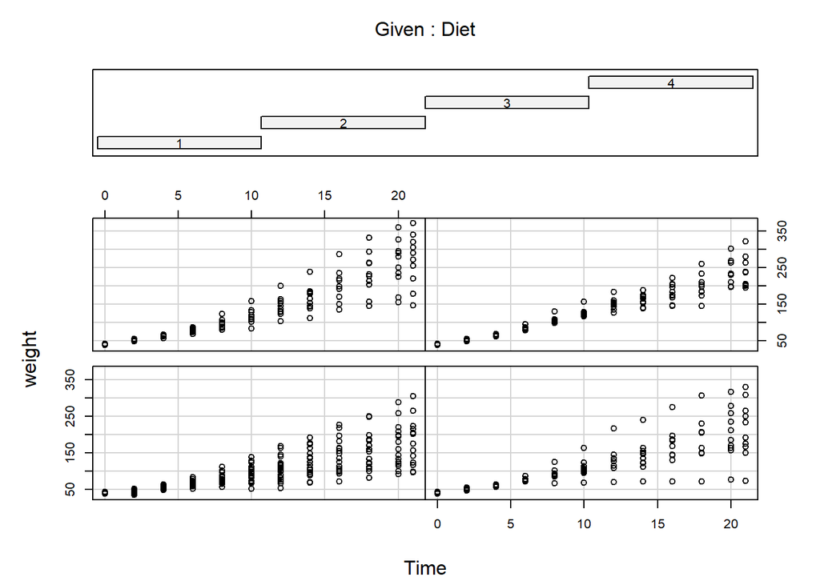

```r
coplot(weight ~ Time | Diet, data = ChickWeight)
```

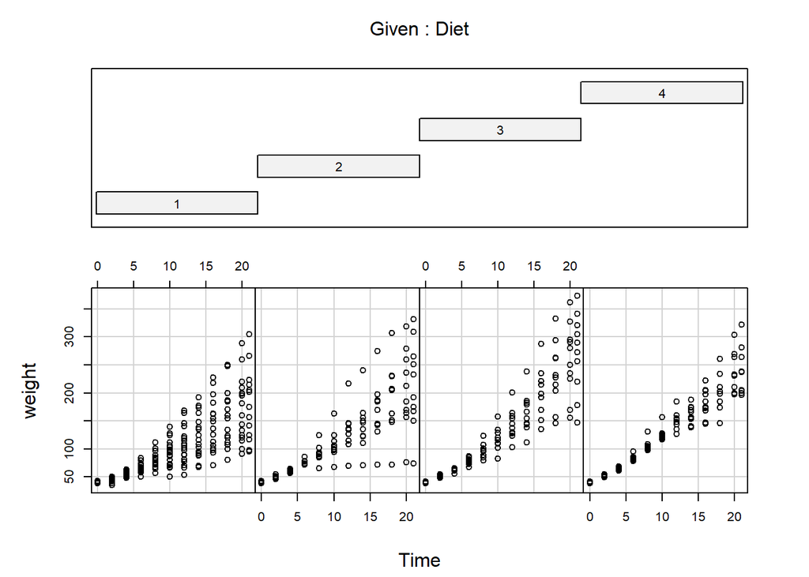

```r
coplot(weight ~ Time | Diet, data = ChickWeight, columns = 4)
```

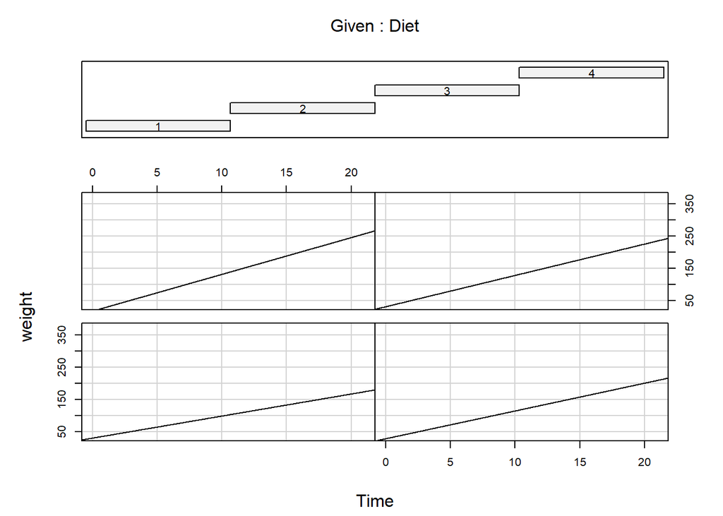

```r
coplot(weight ~ Time | Diet, data = ChickWeight,
       panel = function(x,y,...) { abline(lm(y ~ x)) })
```

```r
# further explanations:
# http://geog.uoregon.edu/GeogR/topics/coplots.html
```

# barplot

[Instructional video on barplot()](https://linkedin-learning.pxf.io/rweekly_barplot)

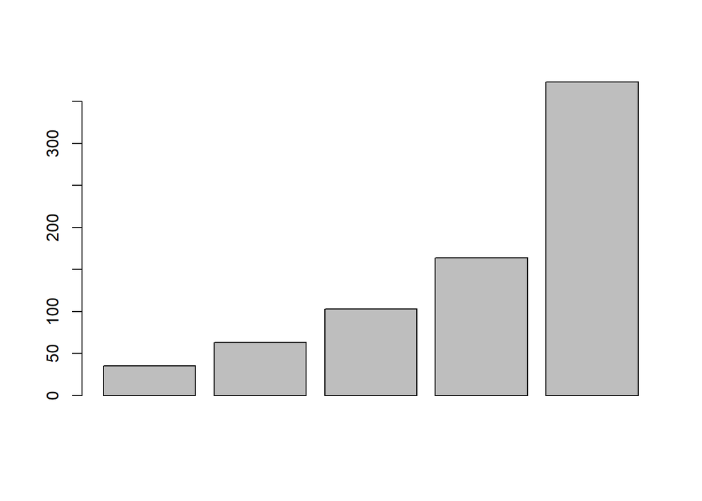

```r
fiveValues <- fivenum(ChickWeight$weight) # just to see what we're working with

barplot(fiveValues) # the simplest of bar plots
```

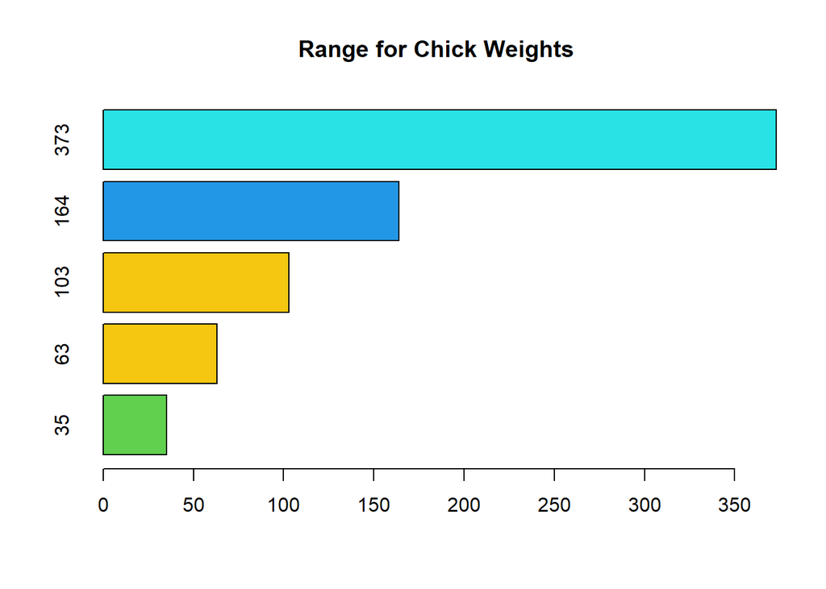

```r
barplot(height = fiveValues,
        names.arg = fivenum(ChickWeight$weight),
        horiz = TRUE,
        col = fiveValues,
        main = "Range for Chick Weights"
        )
```

# piechart

[Instructional video on pie()](https://linkedin-learning.pxf.io/rweekly_piechart)

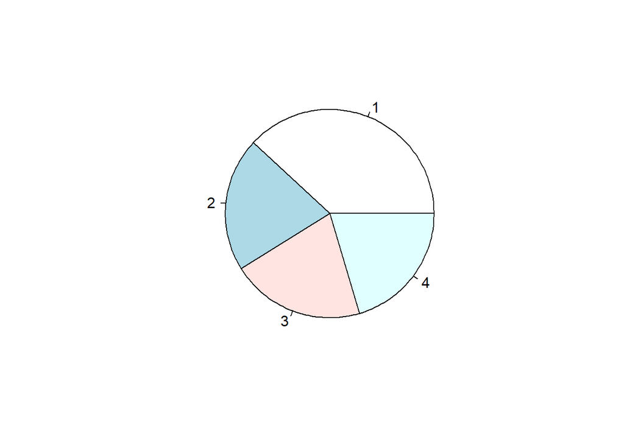

```r
# simple example of a pie chart
pie(table(ChickWeight$Diet))
```

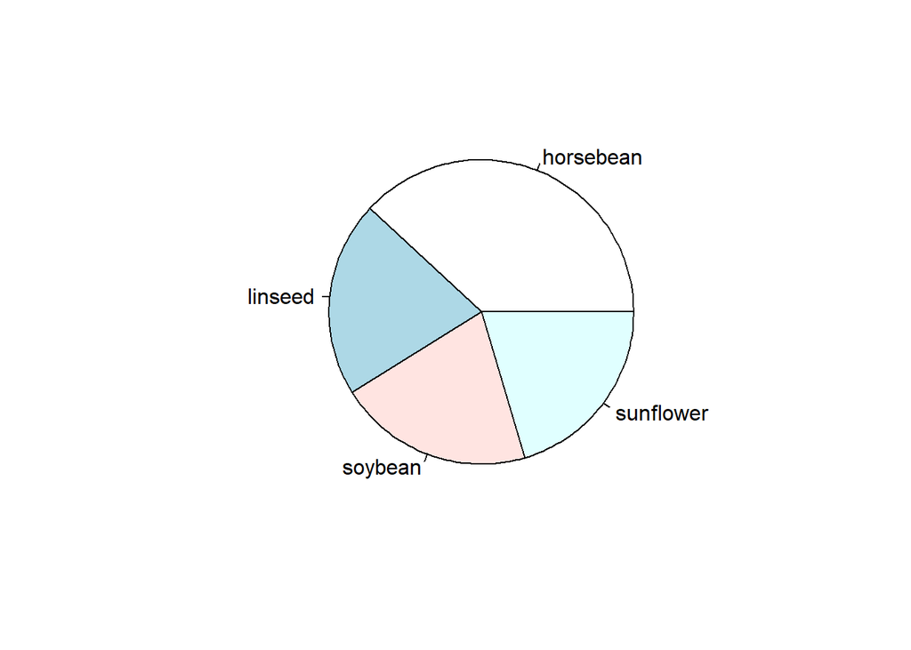

```r
# same pie chart with labeled segments
pie(table(ChickWeight$Diet),labels = c("horsebean","linseed","soybean", "sunflower"))
```

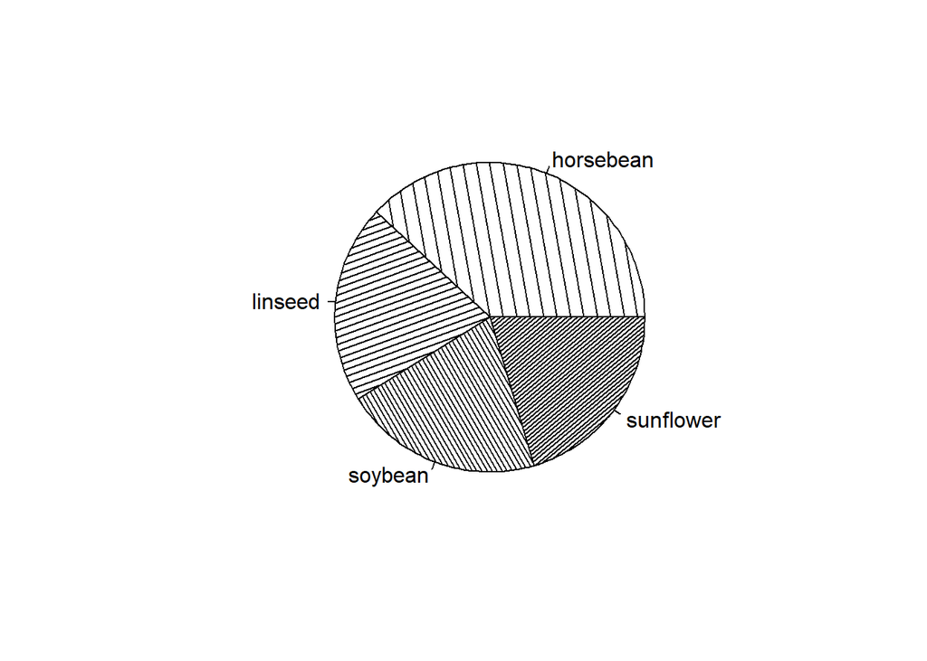

```r
# same pie chart, labeled and with gradients instead of colors
pie(table(ChickWeight$Diet),
    labels = c("horsebean","linseed","soybean", "sunflower"),
    density = 10*1:4,
    angle = 100*1:4)
```

# spineplot

[Instructional video on spineplot()](https://linkedin-learning.pxf.io/rweekly_spineplot)

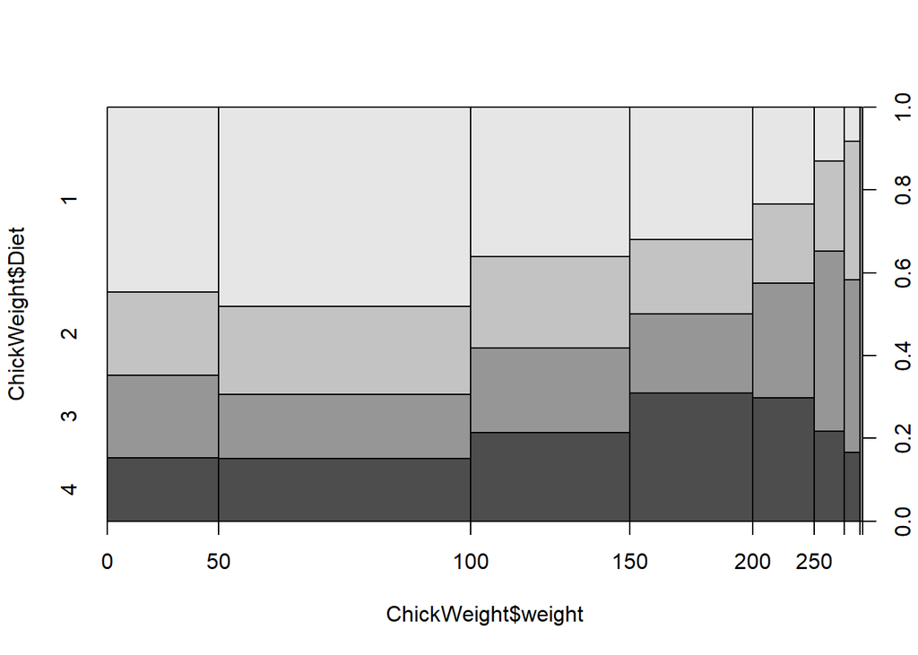

```r
# width of bars = frequency of X
# height of bars = frequency of y

# Y must be a factor and is the dependent variable
spineplot(ChickWeight$weight, ChickWeight$Diet) # spineplot(x,y)
```

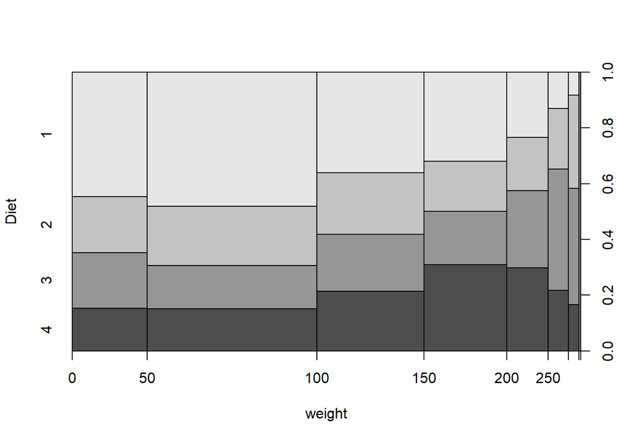

```r
# interesting observations
# Height of bars indicates obs per diet. Diet 1 has more obs
# Width of bars indicates obs per weight. More chicks are weighed between 50 and 100

# or...

spineplot(Diet ~ weight, data = ChickWeight) # spineplot(y ~ x)
```

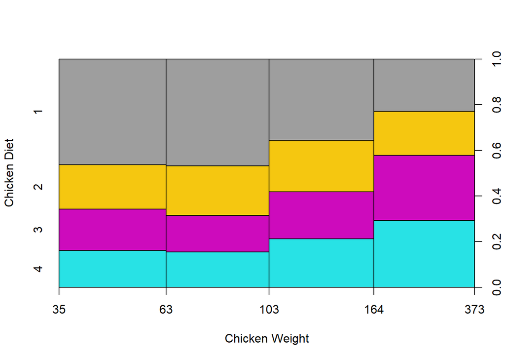

```r
# bells and whistles

spineplot(Diet ~ weight,
          data = ChickWeight,
          breaks = fivenum(ChickWeight$weight),
          col = c(5:8),
          xlab = "Chicken Weight",
          ylab = "Chicken Diet")
```